# Supply and Demand

The power of equilibrium

# Resources

[video not shown]

[04 Slides - Supply and Demand - The Power of Equilibrium](https://drive.google.com/file/d/1aoYtgONUW21s7CP35Ux1oz0Pai3rr1iT/view)

## Readings

Chapter 4 in textbook (optional)

## Games and Apps

- Demand Derivation
- Demand Aggregation
- Demand Comparison

# Content

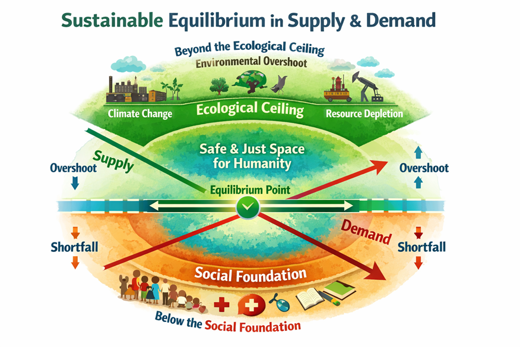

## Introduction and Overview

This lecture examines supply and demand from the perspective of environmental economics, embedding these fundamental economic tools within the planetary donut framework. The central objective is to understand how individual consumer and producer decisions aggregate into market outcomes, and how these market mechanisms relate to environmental considerations.

The lecture proceeds through several interconnected topics. First, we revisit the principles of consumer choice, examining how individuals use indifference curves and budget constraints to arrive at utility-maximizing decisions. From there, we transition to understanding how these individual choices can be represented as a market demand curve through horizontal summation. Next, we build the market supply curve, which involves a simpler analytical framework than the consumer problem because producers optimize profit rather than the more abstract concept of utility. With both supply and demand curves established, we examine market equilibrium and the forces that push markets toward equilibrium outcomes. Finally, we connect all of these concepts to environmental economics and discuss the implications for resource use and sustainability.

[figure not shown]

## From Individual Choice to the Demand Curve

### Review of Consumer Utility Maximization

The foundation for understanding market demand lies in individual consumer behavior. As established in previous material, the consumer chooses what to consume by solving an optimization problem. The key insight is that the optimal bundle of goods, consisting of some quantity of good X and some quantity of good Y, corresponds to the point where the indifference curve is tangent to the budget constraint. This tangency condition represents the combination of goods that maximizes utility given the consumer’s income and the prices they face in the market.

This framework allows for considerable analytical flexibility by manipulating the various inputs into the optimization problem. Interactive visualizations available on the course website allow students to explore how changing parameters affects the optimal choice. The most important exercise involves varying the price of one good and observing how the utility-maximizing quantity responds.

### Deriving the Individual Demand Curve

Consider the baseline case where the price of good X equals 2. Given this price, a particular consumer’s budget constraint takes a specific shape, and the tangency with their indifference curves occurs at a point corresponding to a quantity of good X equal to 25. This is simply the mathematical result of maximizing utility subject to the budget constraint at that price level.

Now consider what happens when we change the price. If we increase the price of good X to 5, the budget constraint rotates inward because the consumer can no longer afford as much of good X with their fixed income. The new tangency point shifts, and in this example, it corresponds to a quantity of only 10 units of good X. The consumer responds to the higher price by purchasing less.

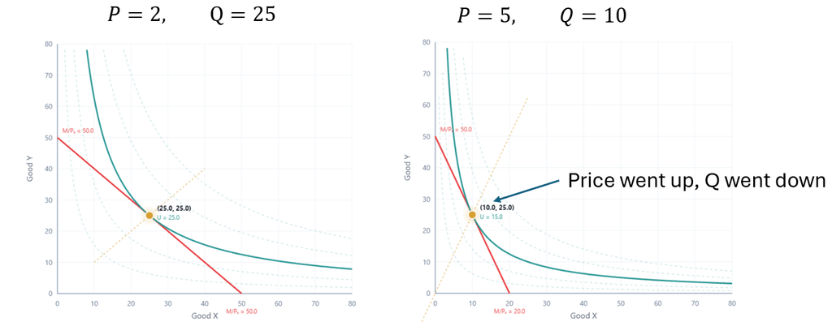

The powerful insight is that for any price of X, we can observe what happens to the utility-maximizing quantity that results from that price. By systematically varying the price and recording the corresponding optimal quantity, we can construct an entirely new relationship: the individual demand curve.

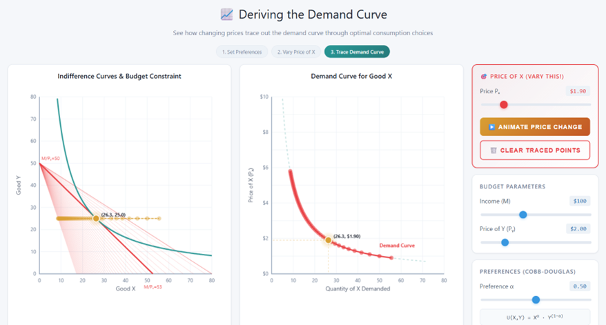

The interactive demonstration on the course website makes this process visible. As the price slider moves, the budget constraint pivots, a new tangency point emerges, and the optimal quantity changes. Each price-quantity combination gets plotted on a separate graph. When all these points are connected, the resulting curve is the individual’s demand curve.

[interactive chart not shown]

### The Mathematical Foundation of Demand

In introductory economics courses, it is difficult to make the connection between utility maximization and demand explicit because doing so requires additional concepts like indifference curves. Consequently, principles courses often simply assert that individuals have demand curves without explaining where they come from. The intermediate approach reveals that the demand curve derives directly from the mathematics of utility maximization subject to a budget constraint. The demand curve is nothing more and nothing less than a description of what happens to the optimal quantity when the price changes, holding everything else constant.

This connection between consumer theory and the demand curve is fundamental. If one accepts the premise that consumer preferences can be represented by a utility function, and that consumers maximize this utility subject to their budget constraints, then the existence and shape of the demand curve follows unambiguously. The logic is internally consistent and mathematically precise, which is why some economists view economic theory as almost physics-like in its rigor.

### From Individual to Market Demand

The analysis so far concerns only one consumer’s demand curve. To analyze markets using supply and demand, we need the demand curve for the entire market, which includes all consumers.

To construct the market demand, we add the quantities demanded by Alice and Bob at each price level. At any specific price, we measure how far each consumer’s demanded quantity extends from the vertical axis, then sum these distances. Geometrically, we are taking the horizontal distance from the price axis to Alice’s demand curve and adding it to the horizontal distance to Bob’s demand curve. The result is the market demand curve, which shows total quantity demanded at each price.

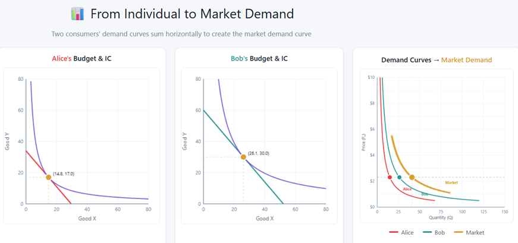

The same interactive tools that illustrated individual demand can demonstrate market demand. As the price varies, each individual’s optimal quantity changes, and the sum of these individual quantities traces out the market demand curve. With hundreds or thousands of consumers, the process is conceptually identical, just involving more individual demand curves to sum horizontally.

[interactive chart not shown]

### The Elegance of Consumer Theory

There is elegance in this derivation of market demand from individual preferences. The entire framework rests on basic assumptions about preferences: that individuals can express whether they prefer bundle A to bundle B, B to C, and so forth, and that these preferences can be represented by a utility function assigning numerical values to different bundles. Given these premises, everything else follows through consistent mathematical reasoning.

This theoretical cleanliness is why consumer theory occupies such a central place in economics. The logical structure is tight, the mathematics is well-defined, and the predictions are unambiguous given the underlying assumptions about preferences and rationality.

### Testing Out many different Demand Functions

[interactive chart not shown]

## Building the Supply Curve

### The Simplicity of Producer Theory

Compared to consumer theory, the theory of the firm is considerably more straightforward. The conceptual difficulty with consumers lies in defining and measuring utility, an abstract and somewhat philosophical concept. What exactly is utility, and how do we quantify satisfaction or well-being?

For producers, the analogous concept is profit, which presents no such difficulties. Profit is simply total revenue minus total cost. There is no deep philosophy involved, just arithmetic. This concreteness makes the supply side of the market much easier to analyze.

### The Data Perspective on Supply

At the introductory level, supply curves often appear as empirical relationships observed in data. One might observe that when the price of coffee is six dollars, a certain quantity is demanded per month. Creating a data table showing quantities supplied at various prices and plotting these points yields the supply curve. This approach treats supply as an observable relationship without delving into the underlying optimization.

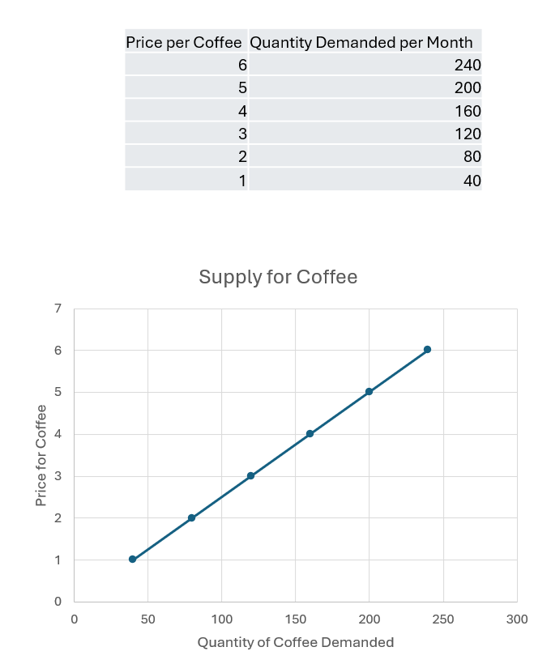

However, a deeper understanding reveals what generates this relationship. The 3000-level treatment goes beyond simply accepting the supply curve as given data and instead derives it from the producer’s decision-making process.

### The Production Function

The producer’s decision is described by a production function, which is directly parallel to how a consumer’s decision is described by a utility function. The production function specifies the quantity produced as a function of the inputs used in production.

In general form, the production function can be written as Q equals f of the inputs. The basic inputs typically included are labor, denoted L, and capital, denoted K. In a standard, non-environmental economics course, these would be the only arguments in the production function.

However, environmental economics requires a crucial modification. The standard approach represents the first of many blind spots in conventional economic theory: the assumption that production depends only on labor and capital while ignoring everything else. Environmental economics explicitly adds natural resources, denoted N, as an additional input to the production function. Natural resources include land, raw minerals extracted from the ground, timber harvested from forests, water, and other environmental inputs.

This modification is fundamental because standard economics has often proceeded as though natural resource inputs are infinite, nonexistent, or irrelevant to production decisions. The failure to account for depletable natural resource stocks in production functions represents a sophisticated argument for why mainstream economics has sometimes guided society down unsustainable paths. By being explicit about labor, capital, and natural resources, environmental economics addresses this critical oversight.

### The Law of Diminishing Returns in Production

To produce more output, the production function indicates that inputs must increase. Adding more labor, more capital, or more natural resources will increase the quantity produced. However, the relationship between inputs and outputs is not linear throughout the entire range.

The law of diminishing returns in production, sometimes called the law of diminishing total productivity, states that at some point, as input factors increase, total product increases at a decreasing rate. This is a special case of the more general law of diminishing returns discussed throughout economics.

The total product curve illustrates this relationship. With labor as the variable input, the horizontal axis measures different levels of labor employed, and the vertical axis measures total product, the quantity Q that results from each level of labor input. The total product curve exhibits three distinct stages.

### The Three Stages of Production

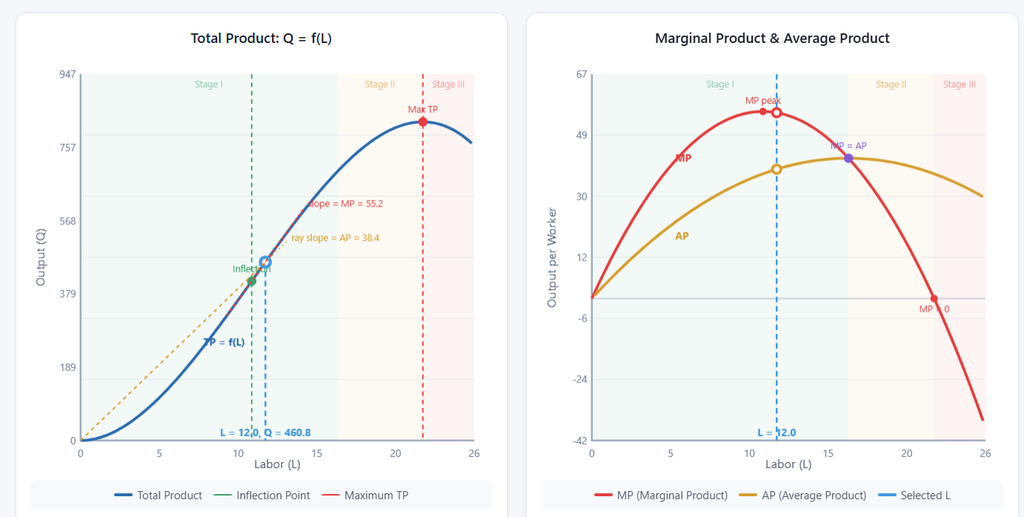

In Stage Two, total product continues to increase but at a decreasing rate. Most actual production decisions occur in this zone. Adding workers still helps, but each additional worker contributes less than the previous one. This is the domain of congestion and diminishing returns proper. The restaurant example illustrates this clearly. In Stage One, a few cooks specialize and coordinate effectively: one does cutting while another handles stirring and frying. In Stage Two, more cooks join the kitchen, and while specialization continues, they begin bumping elbows. The kitchen represents a fixed input with limited space, causing each additional cook to add less to total output than the previous cook added.

In Stage Three, total product actually declines with additional inputs. Returning to the restaurant example, imagine a small restaurant kitchen serving 25 customers at a time. What would happen if a thousand cooks were crammed into that kitchen? Productivity would collapse to zero because the space cannot physically accommodate that many workers. Stage Three is conceptually interesting but practically irrelevant because no rational firm would ever operate in this region.

### From Production to Supply

Introductory economics often asks students to accept on faith that the firm’s production decisions generate a supply function without explaining exactly how this derivation works. The rigorous answer involves the same kind of analysis used for consumers: systematically varying the market price and observing how the profit-maximizing quantity responds.

Interactive tools demonstrate this process. The familiar cost curves from introductory economics reappear: marginal revenue, which equals the market price for a price-taking firm, and the marginal cost curve. The profit-maximizing quantity occurs where price equals marginal cost. The profit box, representing total profit, is maximized at this point.

As the market price moves, the intersection of price with the marginal cost curve shifts, and the profit-maximizing quantity changes. Since the axes already show price and quantity, simply tracing out these profit-maximizing price-quantity combinations directly yields the supply curve. With heterogeneous firms having different cost structures, the market supply curve is the horizontal sum of all individual firm supply curves, just as market demand is the horizontal sum of individual demand curves.

This treatment of supply, which normally occupies multiple lectures in an introductory course, has been condensed but made more comprehensive by explicitly connecting it to the underlying optimization framework.

## Market Equilibrium

### The Power of Equilibrium Analysis

The fundamental reason for deriving both supply and demand curves is to harness the power of equilibrium analysis. The concept of equilibrium provides economists with predictive power because systematic forces in the economy push outcomes toward the equilibrium position.

When an analyst wants to predict how a business should operate under different future scenarios, or when policymakers want to understand the effects of proposed changes, they can simply identify the new equilibrium and make confident predictions that the economy will move toward that point. This is extraordinarily useful for business planning and policy analysis.

### Defining Equilibrium

An equilibrium, whether in economics, physics, or any other system, is a state where opposing forces are balanced. The classic physical analogy is a marble in a glass bowl. If you tap the marble, it rides up the wall of the bowl, but gravity and the bowl’s shape create forces that inexorably pull it back to the lowest point. Whatever perturbation is applied, the marble returns to its equilibrium position.

The economy operates analogously. There is an equilibrium point where supply equals demand, and forces analogous to gravity push economic outcomes toward that point. These forces are excess supply and excess demand.

### The Mechanics of Equilibrium Attainment

Consider what happens when the price is above the equilibrium level. At a high price, consumers respond by wanting to buy less of the good. If video games suddenly cost $159 each, most people would purchase fewer games. Simultaneously, producers would love this high price. New firms might enter the industry, and existing firms would expand production, hiring more workers to increase output.

The result is a mismatch: the quantity demanded falls far below the quantity supplied. This excess supply creates a problem for producers. Their warehouses fill with unsold inventory. Storage space becomes scarce and costly. The natural response is to discount prices to move the excess goods. Stores have sales precisely because they need to clear inventory that is taking up valuable space.

As prices fall, two adjustments occur. Consumers want to buy more of the now-cheaper good, and some producers exit or reduce production because the lower price makes them unprofitable. These adjustments continue until excess supply is eliminated. The price falls all the way to the equilibrium where quantity supplied equals quantity demanded.

### Excess Demand and Price Increases

The reverse occurs when the price is below equilibrium. If video games cost only $1.99, consumers would want to buy far more games, including games they might never actually play. Steam sales illustrate this behavior perfectly: at 99 cents, consumers purchase games they never even open. Low prices stimulate demand dramatically.

However, at such low prices, many producers cannot operate profitably. Less efficient firms exit the market. For fish, those with poor boats or less productive fishing methods cannot cover their costs and must stop fishing. The result is that quantity demanded exceeds quantity supplied.

When consumers want to buy more than exists, secondary markets and price pressures emerge. Concert tickets provide a clear example. When Taylor Swift tickets sell out instantly at the listed price, there is excess demand. Without restrictions, people resell tickets for many times the face value. The listed price is below equilibrium, and market forces push the actual transaction price upward.

More directly, producers recognize that they could charge higher prices and still find willing buyers. They raise prices, which causes some consumers to drop out while encouraging more production. This process continues until the price rises to the equilibrium level where quantity supplied equals quantity demanded.

### Equilibrium as an Attractor

Any point on the supply and demand graph other than the equilibrium point E has forces pushing it toward E. Above equilibrium, excess supply creates discounting pressure that drives prices down. Below equilibrium, excess demand creates bidding-up pressure that drives prices higher. Like the marble in the bowl, the economic outcome is drawn inexorably to the equilibrium point.

This property makes equilibrium a powerful analytical concept. Rather than tracking the complex dynamics of adjustment, analysts can simply identify the equilibrium and confidently predict that is where the market will end up.

## Solving for Equilibrium Mathematically

### From Graphs to Equations

The visual analysis of equilibrium is intuitive, but economics goes further by representing supply and demand as mathematical functions that can be solved explicitly. The graphical representations correspond precisely to mathematical concepts, and calculating exact equilibrium prices and quantities is straightforward once the demand and supply functions are specified.

### Direct Demand and Supply Functions

The direct demand function specifies quantity demanded as a function of price. In general notation, the quantity demanded equals some function D of price. For practical calculations, we specify a linear form. A typical example might be quantity demanded equals 28.67 minus 2.67 times the price. The negative coefficient on price captures the law of demand: higher prices lead to lower quantities demanded.

This is called direct demand because quantity Q appears on the left side as the output of the function, with price P as the input. The direct form is necessary for horizontal summation because we sum quantities at each price level.

The direct supply function has a similar structure. Quantity supplied equals some function S of price. A linear example might be quantity supplied equals 4.5 times price. The positive coefficient captures the law of supply: higher prices lead to greater quantities supplied. This particular function has no intercept, but adding one would not change the fundamental approach.

### The Equilibrium Condition

The key insight for solving equilibrium is simply to set supply equal to demand. All the preceding discussion of excess supply and shortage justifies this simple condition. At equilibrium, quantity demanded must equal quantity supplied.

With specific functional forms, we can solve for the equilibrium price and quantity algebraically. Taking the demand function QD equals 28.67 minus 2.67P and the supply function QS equals 4.5P, the equilibrium condition requires 28.67 minus 2.67P equals 4.5P.

The solution proceeds by isolating P. First, gather terms with P on one side: 28.67 equals 4.5P plus 2.67P, which simplifies to 28.67 equals 7.167P. Then divide both sides by the coefficient on P: P equals 28.67 divided by 7.167, which equals 4. This equilibrium price, denoted P star, is the price toward which market forces push the economy.

With P star in hand, finding the equilibrium quantity Q star is simple. Substitute P star into either the supply or demand function. Using supply, Q star equals 4.5 times 4, which equals 18. The equilibrium quantity is 18 units.

### Verification

The solution can be verified graphically by plotting both curves and confirming that the equilibrium price of 4 and quantity of 18 correspond to the intersection point where supply equals demand. This graphical check ensures the algebra was performed correctly.

### Inverse Supply and Demand Functions

For historical reasons, economists conventionally plot price on the vertical axis and quantity on the horizontal axis. This convention creates a slight awkwardness because mathematical convention typically places the independent variable on the horizontal axis and the dependent variable on the vertical axis. If we express demand as Q equals D of P, then P is the input and Q is the output, but we plot Q horizontally and P vertically, which is backwards from standard mathematical graphing.

To resolve this, economists often use inverse supply and demand functions. The inverse demand function expresses price as a function of quantity: P equals D inverse of Q. Similarly, inverse supply writes P as a function of Q. This formulation makes the graphs more natural because the quantity on the horizontal axis is now the input to the function, and the price on the vertical axis is the output.

The inverse form is simply a rearrangement of the direct form. If the direct demand is Q equals 28.67 minus 2.67P, solving for P gives the inverse demand. The mathematics is trivial, but keeping the forms straight helps avoid confusion.

### Solving with Inverse Functions

Consider specific inverse supply and demand functions. Inverse demand might be P equals 15 minus Q divided by 2, which has a slope of negative one-half and represents a downward-sloping demand curve. Inverse supply might be P equals 6 plus Q, which has a slope of one and represents an upward-sloping supply curve.

Setting supply equal to demand in inverse form means setting the two price expressions equal: 15 minus Q over 2 equals 6 plus Q. The strategy is to isolate Q. Moving constants to one side gives 15 minus 6 equals 9. Moving Q terms to the other side gives Q plus Q over 2.

To combine these terms, they need a common denominator. Q is the same as 2Q over 2, so Q plus Q over 2 equals 2Q over 2 plus Q over 2 equals 3Q over 2. Thus 9 equals 3Q over 2.

Solving for Q requires multiplying both sides by 2 over 3: Q equals 9 times 2 over 3 equals 6. The equilibrium quantity Q star is 6.

The equilibrium price P star comes from substituting Q star into either the supply or demand function. Using supply, P star equals 6 plus Q star equals 6 plus 6 equals 12.

Graphically, these values check out. The price of 12 and quantity of 6 lie at the intersection of the supply and demand curves as expected.

### Flexibility in Approach

Both the direct and inverse approaches yield correct answers. Sometimes one form is more convenient than the other depending on the specific numbers involved. Fractional expressions may be easier to handle using the fraction approach shown above, while decimal forms may be simpler with a calculator. The choice is a matter of computational convenience, not mathematical correctness.

Students should be comfortable with both approaches because different problems may lend themselves to different forms. Being able to convert between direct and inverse representations and solve equilibrium either way provides flexibility in tackling supply and demand problems.

## Connecting Supply, Demand, and Equilibrium to Environmental Economics

### The Environmental Blind Spot Revisited

The machinery of supply and demand developed in this lecture provides powerful tools for analyzing markets. However, the environmental economics perspective requires recognizing what standard theory leaves out. The production function modification that added natural resources N alongside labor L and capital K represents the first of many corrections environmental economics makes to conventional theory.

Standard economics often ignores the depletion of natural resource stocks in its models. By assuming that labor and capital are the only relevant inputs, conventional theory implicitly treats natural resources as infinite, freely available, or simply irrelevant. Environmental economics rejects these assumptions and insists on accounting for the scarcity of environmental inputs.

### Externalities and Market Failure

The equilibrium analysis presented here assumes that supply and demand curves reflect all relevant costs and benefits. Environmental economics challenges this assumption through the concept of externalities. When production or consumption generates costs that fall on third parties rather than the market participants, the supply curve does not reflect true social costs. Similarly, when benefits spill over to non-participants, the demand curve understates true social benefits.

Pollution provides a canonical example. A factory might produce goods with costs reflected in its marginal cost curve, but if production also generates pollution that harms nearby residents, those damages are not included in the firm’s costs. The supply curve thus understates the full social cost of production, and the market equilibrium involves too much production from society’s perspective.

Future lectures will develop these concepts in detail, showing how externalities cause market equilibrium to diverge from social optimum and examining policy tools for correcting market failures.

### Natural Resource Depletion

The depletion of natural resource stocks presents another challenge to standard equilibrium analysis. The supply and demand framework implicitly assumes that production can continue indefinitely at equilibrium levels. For nonrenewable resources like minerals and fossil fuels, or for renewable resources harvested beyond their regeneration rates, this assumption fails.

Environmental economics incorporates resource dynamics into market analysis, examining how optimal extraction rates depend on interest rates, future prices, and physical constraints on resource availability. The open access fisheries problem, which will be analyzed using the supply and demand tools developed here, illustrates how market equilibrium can lead to resource collapse when property rights are poorly defined.

### The Planetary Donut Framework

Embedding supply and demand within the planetary donut framework means recognizing that market outcomes must be evaluated against both environmental and social boundaries. The outer ring of the donut represents ecological ceilings that cannot be exceeded without triggering dangerous environmental change. The inner ring represents social foundations that must be maintained for human wellbeing.

Market equilibria generated by supply and demand may violate either boundary. Prices that fail to reflect environmental damage can push production beyond ecological limits. Inadequate incomes or access can leave people below social foundations. Environmental economics uses the tools of supply and demand while remaining attentive to these broader constraints on what constitutes a desirable outcome.

## Summary and Looking Ahead

This lecture has traced the path from individual consumer choice, through utility maximization and horizontal summation, to market demand. It has similarly derived market supply from producer profit maximization. The combination of supply and demand generates market equilibrium, a powerful concept because economic forces systematically push outcomes toward equilibrium.

The mathematical techniques for solving equilibrium problems, whether using direct or inverse functions, provide practical tools for analyzing markets. These techniques will be applied throughout the course to examine environmental issues including externalities, natural resource management, and policy design.

The key modification introduced by environmental economics adds natural resources to the production function, correcting a fundamental blind spot in conventional theory. Future material will build on this foundation, developing concepts like externalities and cost-benefit analysis that allow supply and demand tools to address environmental challenges.

Students should practice solving equilibrium problems with both direct and inverse supply and demand functions, as these skills will be required on problem sets and examinations. Interactive visualizations on the course website provide opportunities to develop intuition for how changing parameters affect equilibrium outcomes. The mathematical techniques are intentionally kept accessible so that the intellectual challenge comes from addressing substantive environmental problems with powerful analytical tools rather than from computational difficulty alone.

# Transcript

All right, let’s get started. Hello, everybody, and welcome to Lecture 4, where we will talk about supply and demand, but from the perspective of what this says for environmental economics.

Essentially, what we’re trying to do is embed the tools of supply and demand within the planetary donut framework. I just have a piece of art here that I made by hand.

The agenda for today: we’re going to pick up where we left off, which was going through the principles of consumer choice, and how they use indifference curves and their budget constraint to come up with their utility-maximizing choice.

We’re going to transition from that into how do we represent the whole market and all of the choices of individuals making that utility-maximizing choice, and how can this be expressed as a demand curve?

Then we’ll switch over to building the market supply curve. This is much simpler than it is for the individual. Individuals need to think about indifference curves and budgets and all sorts of things. For the supplier, it’s a whole lot easier. Their marginal cost is the demand curve that the individual firm faces, and so we just sort of have it from the data.

Either way, once we have those two things in place, we’ll talk about supply and demand in equilibrium, and transition to how this all relates to environmental economics.

I have another handmade image here of the supply curve for donuts, keeping with our theme.

Actually, I did want to ask the class: I love AI. Does anybody else here love AI? Does anybody hate AI? It’s becoming a divisive thing, so I hope this doesn’t trigger anybody here. I actually research AI on a large NSF National Science Foundation grant for researching how AI can benefit the environment, basically, and so I don’t only like it from the perspective of making ridiculous images really fast.

But nonetheless, I do enjoy that. I only ask because I’m hearing more and more people who are really offended by AI use, especially where it replaces artists, or where it replaces computer programmers. I know a lot of my friends have kids who are about 17 or so, and thinking about what career path they want to go down. The idea of being a computer programmer is a lot more questionable now when we have AI that can code up a lot of things. I still would strongly endorse it, because it’s a way of thinking, not just a way of typing. But nonetheless, I think we’re seeing an emergence of split opinions on AI.

So let’s dive right into the content. Thinking about how do we go from those individual utility-maximizing choices up to the full market demand curve.

Just to remind ourselves where we are: yesterday’s lecture showed how the consumer chooses what to consume. The punchline is the optimal set of good X and good Y is going to be the one that corresponds to this point, where the indifference curve is just tangent to the budget curve.

Where we can go from this is that we can do a lot more with this by playing around with the different inputs into this. You can go onto our class website, and I think I’ve updated most of the links and added some new ones, but there’s a bunch of interactive visualizations.

I won’t click over to it now, because I’ve just copied and pasted some of the key things, but these two different graphs here: all I did was drag the slider for what is the price of good X.

Here, this is the one we’ve seen before. When the price of good X is 2, that tangency point happens to be where a quantity of good X is 25. That’s just the result of maximizing utility subject to their budget constraint.

But what we can do is basically drag that slider, fiddle around with it. Here, this is just when I dragged the slider to the price of good X equals 5. The animation just jumps here immediately, but the new tangency point is now here, and this corresponds to Q equals 10.

Essentially, for any price for X, you can just observe what happens to the utility-maximizing quantity that we get from that price.

The cool thing is, we can create a whole new graph that describes all of the relationship, all of the possibilities between different prices of X and the quantity that a utility-maximizing agent would choose. So what does that look like?

Let me pull up the interactive version. In supply and demand, you can see these interactive versions, and so what I was saying before is, as we drag the price around and solve the utility maximization problem, we’re re-solving for a new budget constraint. When the price of X goes up, as we learned in our principles class, the budget curve will rotate inwards, because you can’t buy as much of good X.

But we’re adding a special ingredient to it. Now, we solve for the optimal number of X’s to buy, and then we plot that over here. All we’re doing here is extracting from this figure, for each different price that we tried out as I’m dragging this bar around, what is the X that was actually demanded by that consumer?

You can do this mathematically, but I think it’s really easy to see. Let’s just try it out. We then plot all those different utility-maximizing combinations, and we get this curve. What is this? This is the individual’s demand curve.

In principles, it’s really hard to make this point because it relies on extra concepts, like indifference curves. We just kind of go from the logic of individuals have demand curves. But what I’m trying to show here is, at a fundamental level, it derives straight from the mathematics of maximizing utility subject to a budget constraint, and the demand curve is just describing what happens, given that optimization, when you drag the price around. That is literally and exactly what we mean when we say the individual demand curve.

There’s one very small point. There’s another interactive version on the website if you’d like it.

We’ve so far been talking about how just one individual’s utility maximization problem can lead to their demand curve. But what happens if you want to solve supply and demand? You actually need the whole market. But this still can also be directly connected back to consumer theory.

The way we go from that information about individuals, or eventually all individuals in society, is we just do what’s called horizontal summation. You might remember that. Here, it’s just saying, let’s add the quantity from Alice to the quantity that Bob demands at each of the different prices. So at this price, here is Alice, here is Bob. The market is just summing those two, and so basically how far it is from the Y-axis to Alice, we just tack that on at the end of Bob’s.

The interactive version that generated this is the same idea: if you dragged the price bar around, and just watched what different quantities of X the individual would want to buy, that’s what will also chart out the market demand curve.

I think this is elegant. I really like it. It comes down to basic preferences. If you can argue that we can have a utility function that expresses those preferences, like I prefer A to B, B to C, and that there’s this utility function that also can put a number on that, the rest of this is all unambiguous.

It’s very clean theory, and this is why some people like to think about economics as almost like physics. It’s very clean theory. If you accept the basic premise about whether you can express it with a utility function, the rest of it is very consistent.

That’s just what we did for consumers, but to fill out the supply and demand relationship, we also obviously need suppliers, and that is much more simple.

Because there isn’t this complex question of what is utility. The idea of what is utility, I have a hard time wrapping my head around that. But if you ask me the question for the producer, what is profit, I have a really easy time understanding what profit is. It’s total revenue minus total cost. There’s no philosophy here. And so it’s a lot easier to define the supply curve.

Basically, this is our Econ 101: we typically just look at it from a data perspective. If we observe that when the price is 6 for a cup of coffee, this is how much coffee is demanded per month, you essentially take a data table like this that describes all of the quantity demanded for all the prices, and plot it. This is literally my Econ 1101 graph.

But I want to go one step deeper on this, because this is a 3000 level class, and talk about what’s underneath that.

Typically, when you do Econ 101, you talk about the supply curve at the very beginning of class, and then eventually, later on, you talk about profit maximization, and average fixed cost, and average total cost, and marginal cost, and all that stuff. But they’re actually also tightly related.

I think the best way to think about it is that the producer and their decision is described by a production function. This is really parallel to how the consumer’s decision is described by their utility function.

The production function is going to be some function f that when we compute it, gives us the quantity produced. Here we’re going to write it in general form first, just saying what are the inputs to this function. The basic ones that are usually included are labor and capital.

Now, if you were in a non-environmental econ class, you would draw the closing parenthesis right there. This is the real first time we see the blind spot of economics: standard econ basically summarizes it down to only labor and capital, and that there is nothing else that goes into the production function.

But because we’re an environmental econ class, this is just the first of many modifications we’re going to have to the basic theory, but we’re also going to have this other input, N.

Natural resources, we’ll call that the N in this equation, and that could be things like land, or raw minerals that you get up from the ground, or timber that you cut down from forests.

This just means that we’re going to be really explicit, not just about labor and capital, but also the depletable stocks of inputs that we have. This is so often and fundamentally ignored by economists that now we’re starting to see, I think, the actual sophisticated argument about why economics has gone down some pretty unsustainable paths: they assume it’s infinite, or doesn’t exist, or doesn’t matter.

So that’s the production function, and from that, we’re going to be able to get our supply function. But first, we have to talk about the law of diminishing returns.

If you want to increase production, this production function, at least, says that we’ve got to increase these inputs. So, we want to produce more, plug in more labor, or more capital, or more natural resources, or probably more of all of them.

You will get more product that comes out of it. That’s what this graph here is going to describe. As you have some sort of input factor, in this case that I have on the screen, it’s going to focus on labor, but it really could be any of them, let’s just call it labor for now. For all the different levels of L you might put into that, we’re going to want to observe what is the total amount produced, basically that Q.

We’ll give it a special term here: total product. There’s going to be some relationship, and the key insight is related to that fundamental law that we’ve talked about, the law of diminishing returns. There’s a special version of that for the producer. It’s the law of diminishing total productivity. Essentially the same thing, but it says that at some point, as you increase your input factors, it’s going to start increasing your total product at a decreasing rate.

Right about here is the point where it switches from more input is increasing our product at an accelerating rate, to here where increasing our inputs still increases our product, but at a decreasing rate.

This is kind of like the startup zone, and this is where coordination among people causes it to be more effective. There’s a lot of cases where two people doing a task are way more than twice as good at it than one person. An easy example is two people using a two-handed saw to cut down a tree. They’re not twice as fast as a single person with that same saw, they’re probably like a hundred times faster, because you need two people on the saw.

That’s this zone. Most production decisions, though, quickly accelerate out of this zone, and so this is where almost all the actual real economics happens, where increasing the inputs does help, but at an ever-decreasing rate.

It’s worth noting that there’s this last zone of where there’s straight-up reductions in the total product. The example there is if you had a total product graph for a restaurant, and your variable input was cooks, and your total product was meals.

Stage one, you’d have coordination causing it to go up at an increasing rate, where we specialize. I do the cutting, and you do the stirring and frying.

Stage 2 is where it’s increasing at a decreasing rate, so now we’ve got a bunch of cooks in the kitchen, and we specialize still, but now we’re kind of bumping elbows, and we could describe this as congestion. This is because the kitchen is a fixed input, it’s only so big. That’s the increasing at a decreasing rate zone.

But then stage three, and this is where the image in your head gets kind of funny, you get to a point where adding more cooks into the kitchen actually decreases your total product. If you think of a small little restaurant that can serve 25 people at a time, what would be the productivity of their kitchen if they had a thousand cooks? Zero. You can’t even fit that many people in a kitchen. This part, frankly, is not very interesting, maybe a little funny, but most of the decisions are always going to happen in this part here.

That was Econ 101. In Econ 101, you’re given the sort of take-it-on-faith that this can be expressed as a supply function, but typically, you don’t learn how exactly do you go from the firm’s profit-maximizing decision to the supply function. We just tell you what it is.

But the answer here is I’ve made a tool for this one too. It’s on the website. We’re going to do the same thing as before that we did for the consumer, where we dragged the price around and just watched what their choice was for how much Q to buy. Now we’re going to do the same thing. We’re going to drag the market price around and see what happens to the profit-maximizing quantity the producer produces.

Hopefully these look really familiar from your Econ 101 classes. We spent a lot of time on this. Price is the marginal revenue, here’s your marginal cost curve. The profit-maximizing one is always setting price equal to marginal cost. I know I’m going fast, but I’m presuming everybody has studied this very well. The other things here are, like, that’s the profit box, and so this is the point that makes that profit box the largest.

What we can do is, when we drag around that, we can just observe what is the quantity they produce. We’ve already got it expressed in terms of the price and the quantity. So this is where it’s different than the consumer problem, where we had one good versus the other good. Here, we already have it as price versus quantity, and so just simply dragging around the market price and adding together all of the different firms, you might have heterogeneous firms, that’s how you can trace out the supply curve.

So that’s supply. We just did supply, which is normally 5 lectures or whatever, but we did it more comprehensively and in only about 10 minutes, so we’re definitely past Econ 101.

Why do we want to do this? It’s because we want to use the power of equilibrium. If I had a theater voice, I would have said that with a much more resonating tone. I want to talk about equilibrium, how it derives from the combination of supply and demand, and why it’s so powerful.

The powerfulness of it essentially comes down to: there’s all sorts of forces in the economy that push the outcomes towards the equilibrium. This is useful because you can make strong predictions about what is likely to happen.

The punchline is that if you can define mathematically what the equilibrium price and quantity would be, if you’re some analyst and you’re wanting to make a prediction for how should your business operate under different future scenarios where we’re worried the price is going to change, you simply assume the equilibrium’s going to happen, and make a strong prediction that that’s the new price and quantity that will happen. That’s very useful business information if you want to make a lot of money.

The definition of an equilibrium, whether it’s in an economy or a physics class or in a bowl, is a state of the system where the opposing forces are balanced. The classic example of an equilibrium would be this marble in this glass bowl. You could knock it out of there, you could give it a tap, and it would ride up the wall of the glass bowl here, but there’d be some set of forces, in this case gravity and the shape of the bowl, that causes it inexorably to go back to the equilibrium point. Whatever is the lowest point of that bowl is the equilibrium.

The economy, as we’re going to argue, is essentially the same way. You did this in Econ 101, but I’ll go through it very fast. The punchline for supply and demand is that, just like the bowl, there’s an equilibrium point here, and just like gravity pulled it to the bottom of the bowl, two different forces, in this case we’ll call them excess supply and excess demand, are going to push the decisions of the producer and the consumer right to this point.

What does that look like?

First off, if anybody says solve the equilibrium, that’s really easy, just find the point. You don’t even have to think about this. Just, as long as you remember equilibrium is where supply equals demand, the rest of the logic holds. But I still want to talk through why that statement is something that you can simply memorize.

The answer is that any other point besides P star is going to have something go wrong. If the price for some good goes way up, what’s going to happen to our two different agents in this system?

The consumers represented by the demand curve: well, something just got really expensive, I’m going to buy less of it. If video games now cost $159 per game, I would buy fewer. That’s basic demand, and so I would want to consume less.

But if, for some reason, video game companies thought that they could sell their computer games for $159, probably a whole bunch of new firms would enter, even existing firms would produce more, hire a bunch more workers to plug into their existing production function. They would really love it if they could produce this really high level of video games, but the problem is these don’t match. The quantity demanded will be way below the quantity supplied at this price.

What’s going to happen is producers will have an incentive to lower prices. Here it’s really easy. If you think about what happens when a store buys too much of a good, it’s filling up their back room, like their warehouse is literally overflowing with toilet paper or something. What are they going to do? They’re going to have a sale, try to get rid of it as quick as possible, because it’s literally a cost for them. They’re running out of storage space, but also it’s just a real hassle. So they’ll do discounts. They’ll lower the price. Some version of “hey, we have to get rid of all this extra stuff that’s taking up space,” and so they will essentially lower price.

That will cause a downward pressure. Suppose it goes a little bit down: two things will happen. Consumers will want to buy more of that thing, because it’s a little bit less expensive, and some of those producers may not want to produce anymore at that lower level. But we still, with this intermediate step, would have more excess supply, so the discounts would continue all the way down until there is no excess supply.

That’s what happens when the price goes above the equilibrium price. We get surplus.

The same thing but in reverse happens when we have a price that is below the equilibrium price. What do we have then? If now, all of a sudden, video games cost $1.99, I’m going to buy a lot more, even ones that I might not play very much. And if you look, I have a lot of games on my Steam account, what I use to buy games, and when it goes on sale, I buy a lot of games, and I’m like, actually, I don’t want to play that. I probably have about a third of my games with zero hours of playtime, never even opened. That’s because they have sales. For 99 cents, I’m like, man, maybe I will buy this.

The point is, I would have a higher level of demand at this really low price, but the problem is companies that produce things might not be profitable with that really low price. Video games is sort of a bad example because you’re producing a digital thing which can be reproduced for free, but it’s a lot easier to think about something like fish.

There’s people that are really bad at fishing or don’t have a good boat. They can’t be as productive as those ones that have an awesome fishing boat, and so they will drop out of the market.

Regardless, it’s going to cause this wedge in between supply and demand, where I want to buy a lot, but the producers only want to produce a little. What happens when you have consumers wanting to buy more than exists?

Think of concert tickets. That’s a classic example of something where they sell out real quick if it’s Taylor Swift or something. What happens? There’s a secondary market. You can then resell your tickets, and they’re trying to reduce this with Ticketmaster and different approaches, because it feels unfair, but if those safeguards weren’t in there, people will buy it for $300 and sell it back immediately to somebody for $1,200.

This is sort of the opposite of discounts. They’re giving like a negative discount. They’re willing to pay more. They will find a way, through black markets or reselling or whatever, to increase prices.

But frankly, what will probably happen is the producers will see, “Hey, wait a minute, I could get away with a higher price. I get to sell it for more,” and so that’s probably the more direct way. But regardless, they will keep increasing the price when they think people will keep on buying it. That will continue until the quantity supplied equals the quantity demanded at our magical equilibrium point.

All I’m trying to say is that anywhere on this graph besides point E has these forces conspiring to push it towards E, and so that’s why I drew it as a bowl.

So that was the intro.

But I want to solve this. The fun of economics is that it’s not just graphs. The graphs are there unambiguously representing mathematical concepts, and we can then actually compute these things.

I want to start to introduce the first of our mathematical approaches to this. So far, we haven’t had you write much math down. That’s technically math, but not too much. I want to now do it, where we’re going to have demand curves that are represented by basic line equations.

I’m going to skip the part about horizontal summation. This is just a different representation of the fact that the market demand curve is a horizontal summation. Here, I’ve given you some extra notation: consumer 1 had this demand curve, consumer 2 had this demand curve. We can add them together and get this demand curve, at least from here on below. You can ignore that from now, but we’re going to focus on this exact expression.

So, let’s get started with that.

The demand curve, when we compute it, is going to get us the quantity demanded. That’s the output of it. The generalized expression for it, before we give it a specific form, we’ll just call it the demand function, is going to be an input of price.

What we’re going to add now, with that part underneath the market line, is a specific version of this general form, and that will be something that you could plug into a calculator.

Those are just the three different ways of expressing the same thing, but that’s what we’re going to use. One important note: this is what’s referred to as direct demand.

Intro skips over this, but a direct demand curve is one where you look at the quantity demanded as the output of the function. In other words, Q is on the left, and P is the thing you plug into the function. That’s called direct demand. That’s necessary for the horizontal summation, because that’s what we’re summing over. We want to sum the quantities this way.

The other part of this is the direct supply curve. Just like with the consumer, here’s another example of how we get market supply. We have a supply function for firm 1 and for firm 2, and we’re just going to aggregate them with that horizontal. Let’s focus on this one.

QS is going to be equal to 9 halves, or 4.5, times P.

That’s going to be just a basic upward-sloping one. Before, we had the downward sloping one because of the negative slope on price. Here, we have a positive slope on price. It doesn’t have an intercept, but I could have added that without loss.

Who solved these before? This is like the canonical thing you do in intermediate, right? It’s right before you solve the Lagrangian, if you do. But I’m going to just walk through it again, because we’ll have these on problem sets, and the reason I’m doing this is because this will be the tool that we’re going to use to understand some very important concepts, like externalities, open access fisheries, and stuff like that. So let’s just get a good reminder on how we solve this.

The punchline that we just talked about before is set supply equals demand. It’s our key insight. There’s a lot of work to get to the statement about the excess supply and surplus and shortage, but let’s just start here. That means we can just take these two things and set them equal to each other.

Let’s do that. I’ll just walk through the math on the board. It’s on the slide too, obviously, but I just like to walk through it on the board so you can do it by hand. I would recommend following along with a pencil or your screen or whatever, because the act of doing it will help you do better on the test.

We’re just going to write the quantity demanded on the left-hand side. Here’s the magic. We’re going to know that it’s going to equal 4.5P. All we have to do now is solve for P by getting P by itself, so how would we do that?

First, let’s get the coefficients by itself, and the things that are multiplied by P together, so it would be 4.5P plus 2.67P. So you could calculate what that is. Simplify it further: 28.67 equals 7.167P.

Now what do we do? Flip that over there, and I’m going to now put P on the left-hand side. Equals 28.67 divided by 7.167. That’s a calculator one that I couldn’t do, but when you compute that out, I’ve chosen the numbers very precisely so it equals 4.

We’ll give that one a P star, because now we’ve got what we want, the equilibrium price. The world is conspiring to make price equal to 4, and anything else in the world will feel out of whack.

Once you have P star, it’s easy to get Q star. Just plug 4 into either one of those supply or demand functions. This one’s probably easiest: Q star equals 9 over 2 times P. But now we’re going to plug in 4 because that’s the P star, and that will equal 4.5 times 4 equals 18.

Any questions on the algebra?

I don’t want to challenge you on the algebra. I’m hoping this is easy, but that’s the point. I don’t want to have the class be hard because the algebra is hard. I want the class to be hard because you’re addressing hard challenges with powerful tools.

Just tying all the pieces together, here’s one graph that shows it all. P star is 4, Q star is 18, and so we know we did our algebra right when that combination of P and Q indeed goes to the point where supply equals demand.

So that was the direct version of this problem. Often, however, actually more common, I would say, is we deal with the inverse supply and demand.

What’s going on here is, for historical reasons, dumb reasons, economists always put price on the vertical axis of our plots. That’s just how we draw it. There’s no reason it has to be that way. You could put price on the horizontal axis and quantity on the vertical axis, but for historical reasons, we just keep doing it that way.

Or, in other words, we express it as quantity demanded is a function of price. The problem is it’s very unintuitive to draw graphs that way, especially when you’re doing them from the core mathematics. The reason for this is usually when we have functions in mathematics, we’re thinking of the horizontal axis, X, as what’s plugged into the function, and Y is the result of the function.

If we wanted to make our expression of supply and demand match that logic, we would use what are called inverse supply and demand functions. That’s basically saying, instead of the demand function taking P as an argument, we’re going to flip them around.

Indirect demand now would say that we’re going to solve for P by plugging in different quantity demanded. It’s sort of trivial. You could take these equations that I have here on the board and just rearrange them. Is it price on the outside or the inside? It’s mathematically easy, but this is just a lot easier to plot. So let’s give some specific ones.

15 minus Q divided by 2. Basically it’s saying it has a slope of negative 0.5, so we have our desired downward-sloping demand curve. An inverse supply, it’s an inverse one so we’re putting the Q in here instead of the P, just like here, equals 6 plus Q. So it’s upward sloping at a slope of 1.

We’re going to practice solving this one too. It’s pretty similar to what we did. The logic is just going to be the same. Set supply equals demand, and I’ll put it in the right order this time.

S equals D means we’re going to have 15 minus Q over 2 equals 6 plus Q, and so our strategy is to isolate Q. How do we do that? Let’s first get these over onto one side, so 15 minus 6 is 9. And we’re going to move this one over here, so Q plus Q over 2.

Then how do we do this one? That’s probably the place where most people will get tripped up. If you want to be able to add Q to a Q over 2, the problem is they have different divisors. So what we really need to do is have them have the same divisor. We’re just going to put a 2 on both sides. It’s the same thing, obviously, because this is 1.

We have 2Q plus 1Q is 3Q, and they had the same root. Our answer is 9 equals 3Q over 2.

A few more steps to get our Q star: we’re going to multiply by 2 thirds, which means we pull the 2 thirds next to the 9. That’s pretty easy to see as 6.

So we have a Q star of 6.

Then we’re just going to get the other thing we want by plugging it into one of our supply or demand equations, but using the Q star. This one’s real easy: P star equals 6 plus Q star equals 12.

Graphically, it looks nice. We’ve got it. That looks like it’s about 12, that’s obviously 6, and so it all worked.

Any questions on the mathematics of it?

You will have these on our problem sets. It depends on the question. Sometimes the fraction way makes more sense. Here, I did it where it’s probably easier to think about it in terms of a decimal, because I think you can just do 0.5 plus 1. I will not grade you up or down regardless of how you choose to do it, but sometimes one way is more error-prone than the other, so maybe try both depending.

I’ve done that in past years, so maybe, well, the answer is I haven’t made the tests yet, so I don’t know, but now that that’s on my mind, I think the answer just increased in likelihood.

So let’s take this one and just drop that middle part. This is indirect, or inverse demand, sometimes called indirect demand. But to get the direct demand, we’re just going to flip it. I just moved the 6 over to here, and then put the Q on the left-hand side. Same with the other, you could do something similar.

Any other questions?

We went faster than expected, which is good.

In terms of where we’re going and getting a sense of the trajectory: as you see, I’ve been updating the website. It’s being populated. Here are the slides for today. Obviously not a video yet because I still have to do my YouTube video editing. But the other things are filled in.

Here I’ve got the utility maximization games. Do play around with those if you want to. I think I corrected all the links that were done wrong the other day.

I haven’t made the assignment yet, but in terms of assignments coming up, what I’m thinking is right after class here, I’m going to put this up. That’ll be, just like the first one, a really quick response, might take you less than 5 minutes, but just keep you engaged with it. That’ll be due on Monday, but after it’ll be due at the end of Monday, so technically you can do it after class on Monday.

On Monday is when we’ll also have our first problem set assigned.

So far, there still haven’t been any readings, because I’m just creating the content, and so the reading is technically the website. But we’re going to start, once we start getting into things like cost-benefit analysis, we’re going to refer back to our actual textbook. Did everybody succeed at getting access to that? I just wanted to make sure that it was downloadable. Did anybody succeed at downloading it? It’s a little dicey because you have to be logged in.

All right, let’s call it a bit early, and I will follow up on Canvas announcements with what next steps are coming. Thank you so much.

# Appendix

## Learning objectives

After this chapter, you should be able to:

- Explain what **supply** and **demand** represent in economic terms.
- Interpret a simple **market equilibrium**.
- Define **consumer surplus**, **producer surplus**, and **total surplus**.
- Explain what economists mean by **“efficiency”**—and what they *do not* mean.
- Use welfare tools to analyze simple environmental policies.
- Connect market outcomes to the **Doughnut**: when markets undershoot social needs or overshoot ecological limits.

## From individual choice to markets

In Chapter 3, we focused on individual choices under constraints.

Markets are what happen when:

- many buyers with preferences meet
- many sellers with costs and technologies
- under a set of rules (institutions).

### Demand

The **demand curve** summarizes:

> How much people are willing and able to buy at different prices.

It slopes downward because:

- when a good is expensive, fewer people buy it,
- when it is cheap, more people do.

For environmental goods, “price” is often hidden:

- commuting time,
- health risk,
- noise,
- ecosystem degradation.

Demand still exists—even when no money changes hands.

### Supply

The **supply curve** summarizes:

> How much producers are willing and able to sell at different prices.

It slopes upward because:

- producing more usually requires higher-cost inputs,
- the easiest units are produced first.

In resource contexts, rising supply cost often reflects:

- moving to poorer-quality land,
- drilling deeper,
- harvesting less accessible stocks.

## Market equilibrium

Where supply and demand intersect:

- quantity supplied = quantity demanded,
- the market “clears.”

This is **not** a moral optimum.  
It is simply the outcome given:

- preferences,
- technologies,
- and institutions.

Equilibrium can be:

- socially harmful (e.g., too much pollution),
- inequitable (e.g., basic needs unmet),
- ecologically destructive.

Economics does not say “markets are good.”  
It says: *“Given these rules, this is what will happen.”*

## Welfare: who gains, who loses

Economists summarize gains from trade using:

- **Consumer surplus (CS):**  
  how much buyers gain because they pay less than they were willing to.
- **Producer surplus (PS):**  
  how much sellers gain because they receive more than their minimum cost.

**Total surplus = CS + PS**

In a simple, well-functioning market with no spillovers:

- competitive equilibrium maximizes total surplus.

This is the origin of the claim that markets are “efficient.”

But notice:

- It counts only gains and losses *inside the market*.
- It says nothing about:
  - distribution,
  - unmet needs,
  - or ecological damage.

Efficiency is not justice.  
Efficiency is not sustainability.

It is just a benchmark.

## A simple environmental policy example

Consider a city with heavy car traffic.

- Without policy:
  - Drivers enjoy convenience.
  - Gas stations earn profits.
  - Residents suffer pollution and noise.

In a standard market diagram:

- CS = drivers’ benefit
- PS = sellers’ profit
- Pollution damage = **not counted**

A congestion fee or fuel tax:

- raises the price of driving,
- reduces quantity,
- lowers CS and PS,
- but reduces pollution and congestion.

From a welfare perspective:

- Some surplus is lost in the market,
- but external damages fall.

If the policy is well-designed:

> The gain from cleaner air and less congestion exceeds the market loss.

This is the logic behind “corrective” policy.

## Markets and the Doughnut

The Doughnut asks two questions of every system:

1. Are people falling below the **social foundation**?
2. Are we overshooting the **ecological ceiling**?

Markets can fail on both fronts.

### Undershooting the social foundation

Markets may not provide:

- affordable housing,
- basic healthcare,
- clean water,
- energy access.

Even if markets are “efficient,” people can be excluded by income constraints.

### Overshooting the ecological ceiling

Markets often:

- ignore pollution damages,
- underprice natural capital,
- reward extraction over regeneration.

Left alone, they can push activity beyond safe ecological limits.

So the policy problem becomes:

> How do we reshape markets so that their equilibria lie *inside the Doughnut*?

That requires:

- changing prices (taxes, subsidies),
- changing rules (standards, zoning, rights),
- and sometimes changing what can be traded at all.

## Why this chapter matters

Supply, demand, and welfare give you:

- a way to predict responses to policy,
- a way to see who gains and who loses,
- and a disciplined language for tradeoffs.

They do **not** tell you:

- what society should value,
- where ecological limits lie,
- or how much inequality is acceptable.

Those come from ethics, politics, and science.

Economics gives you a map of consequences.

The Doughnut tells you where you want to go.

## Open resources you can remix for this chapter

All are compatible with a CC BY-NC-SA Quarto book.

- **Principles of Economics (UMN Libraries Publishing, CC BY-NC-SA)**  
  Use for: supply and demand, equilibrium, consumer/producer surplus.  
  https://open.umn.edu/opentextbooks/textbooks/principles-of-economics
- **InTeGrate teaching materials (many CC BY-NC-SA)**  
  Use for: applied market examples in climate, energy, and resources.  
  https://serc.carleton.edu/integrate/teaching_materials/index.html

Figures and explanations can be adapted directly with attribution.

## Exercises

1. **Market diagnosis.**  
   For each case, describe one reason the market outcome may lie outside the Doughnut:
   - 1. Urban housing markets
   - 2. Global fossil fuel markets
   - 3. Industrial agriculture
2. **Who gains, who loses?**  
   Consider a carbon tax.  
   Identify:
   - one group that likely loses,
   - one group that likely gains,
   - one non-market benefit.
3. **Efficiency vs sustainability (short essay).**  
   Explain why a market outcome can be “efficient” and still be socially or ecologically unacceptable.

## Chapter roadmap

- Next, we move from “how markets work” to “how markets fail.”
- You will learn how externalities, public goods, and commons break the link between private incentives and social outcomes—and why environmental policy is fundamentally about repairing that link.